# FIT3152 Assignment 1

Trust in the Community and Government may very well likely be a good correlation towards Pro-Social Behavior. We hypothesize that the more likely they trust in their community and government for handling COVID-19, the more likely they would be more willing to help out other people (Pro-Social Behavior). Let us analyze the statistics.

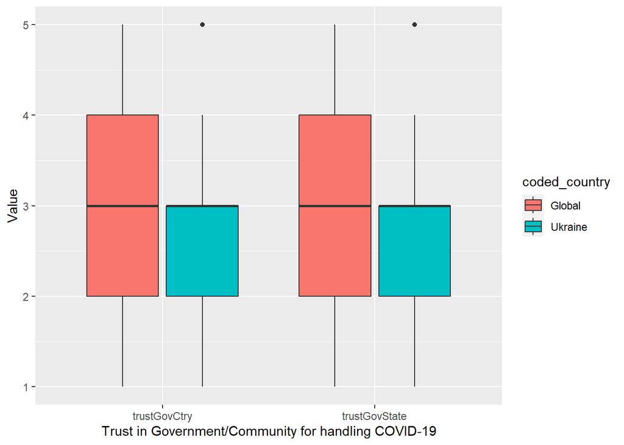

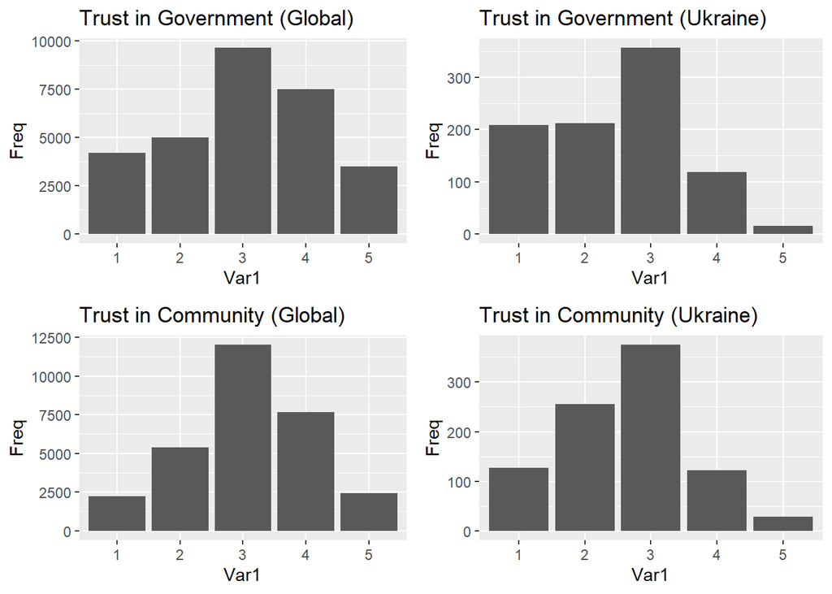

We can see here that the Trust in both Government and Community is lower in Ukraine than the global score. Generally Ukrainians trust their community and their government less in whether they would be taking the right measures to tackle COVID-19. What is interesting to note is that the 5th value, meaning that the person responding trusts the government and/or community a great deal for handling the pandemic, is rarely seen from Ukrainians.

This may be a useful indicator of finding the reason on why Pro Social behaviors are lower in Ukraine. Could there be a correlation here? We will be looking at this in 2(b)

Next, let’s dive into the community injunctive norms for the coronavirus. This data shows how much they would agree that the community should self-isolate (c19NormShould) and do self-isolate (c19NormDo), and to what extent does their community develop strict rules to fight against COVID (c19IsStrict), punish people who deviate from such rules (c19IsPunish) and how organized they are handling the pandemic (c19IsOrg).

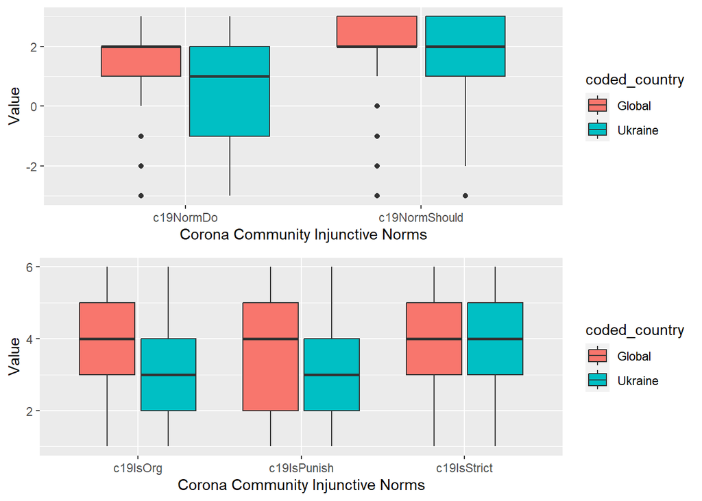

The box and whisker plots show that Ukrainians on general do not self-isolate as much as the Global population. In fact, less of the people surveyed in Ukraine think that they should be self isolating.

As for how they think their community is handling against the virus, it shows that Ukrainians think that the community is making strict rules to the same extent as their Global counterparts. However, they are less likely to enforce it as c19IsPunish is lower. Ukrainians also think that their community is not as well organized in handling the pandemic as compared towards other countries.

What about their social discontent? Since there may be correlation between trust in government/community and pro-social behavior, surely social discontent does too?

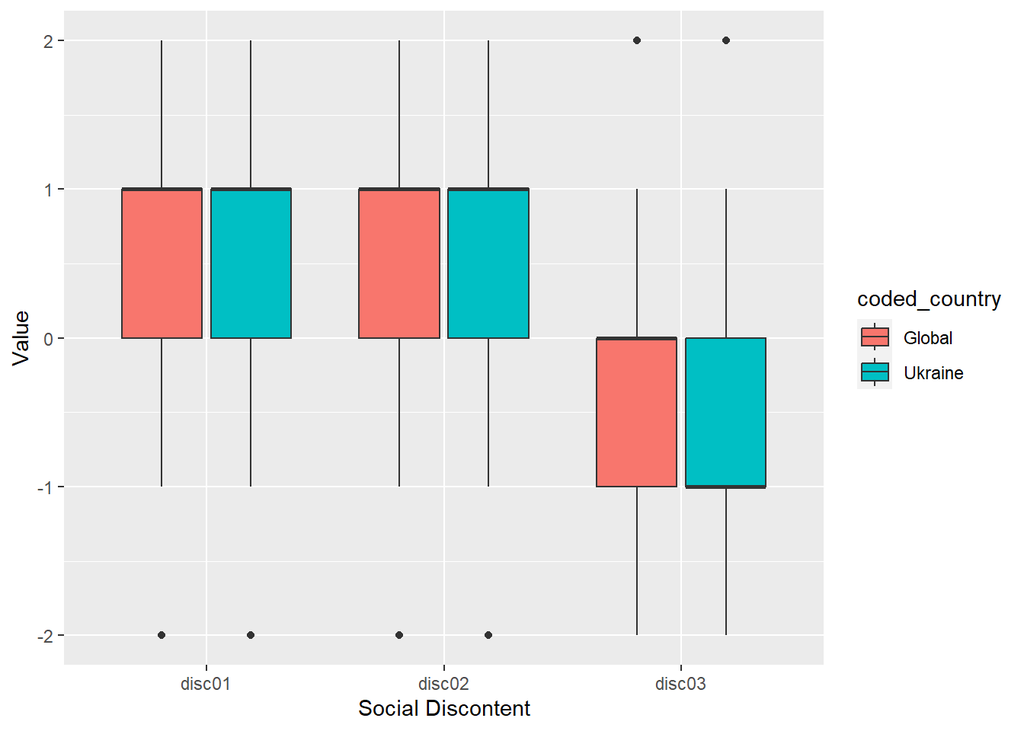

Social Discontent is generally the same in their statistics, the only difference here is disc03, where the median is lower than that of the Global Average. This means that Ukrainians are slightly less satisfied with society than everyone else.

Lastly we will be diving into the statistics of their employment level.

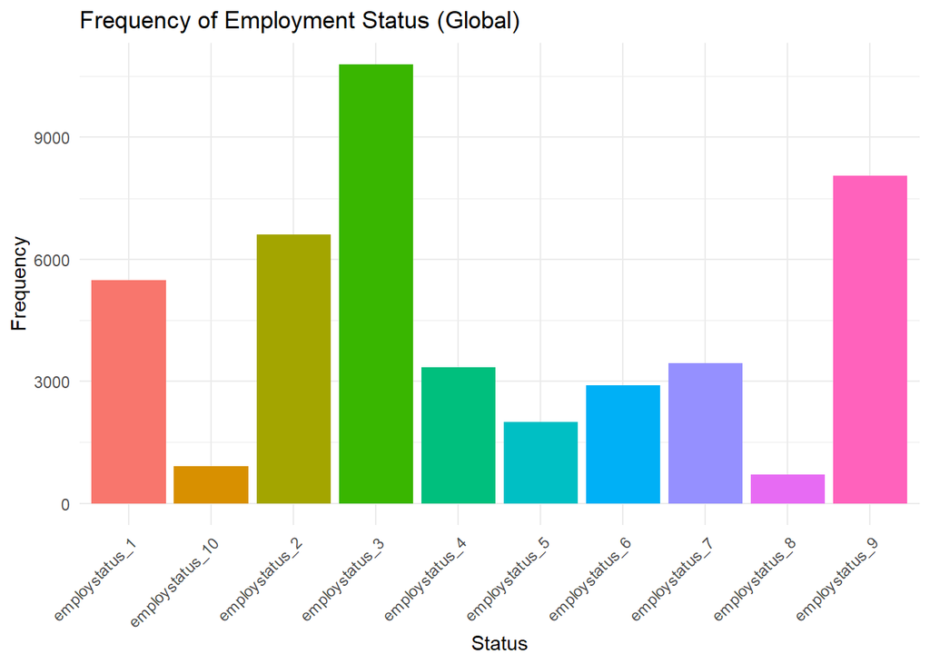

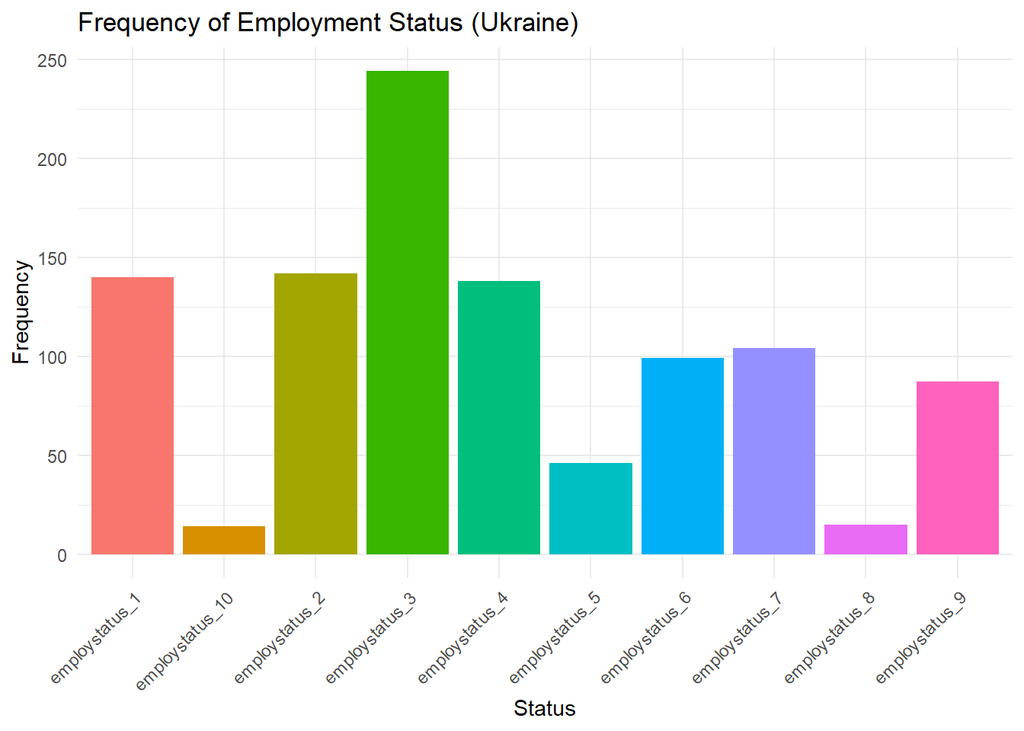

From our data most people have employstatus_3 checked, meaning that most are working at 40 or more hours a week. What is interesting to see is that Ukraine’s employstatus_4 value is relatively higher, signalling that they are more unemployed people in Ukraine that is actively looking for a job. This could contribute towards their higher perceived financial strain (PFS) and Job Insecurity (jbInSec) that we have analyzed earlier. There are a lesser proportion of Students from Ukraine who have taken the survey that the global average as well.

Question 2(b)

There may be several reasons on why this may be the case, and we will be diving into that deeper. First off, let’s build a linear model with the pro-social behaviors being the label, and the other predictors as the factors to determine the p-value of these predictors to state which predictors are the strongest.

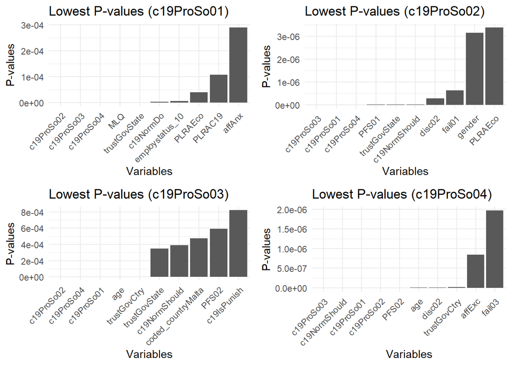

Based on the data that we have gotten above. We are trying to find the strongest predictors that would influence the Pro-Social behaviours in a global-scale. We will be locating the strongest predictors that would affect the score of the pro-social behaviours using the p-value. We can see that the pro-social predictors heavily affect each other on the score that they would get. Let’s dive deeper to see each of the other strong predictors using a correlation matrix.

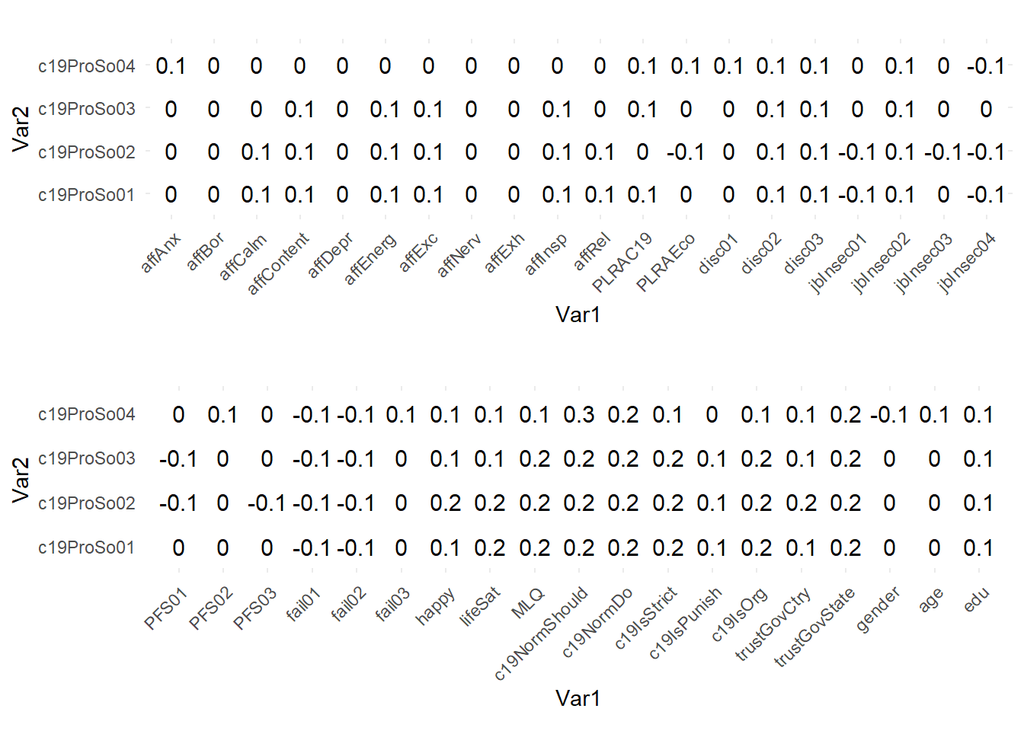

From the plots above and the summary of the lm model that we have gotten we are able to find the strongest predictors based on the correlation and the p-value of the given predictors.

However, we can notice that the higher correlations here do not necessarily equal to the lowest p-values that we gotten in the linear model for each of the behaviors. We will be using the predictors based on the p-values instead as they have been tested to be highly against the null hypothesis. This is due to their extremely low P-values that will indicate how likely they are to be as a strong predictor.

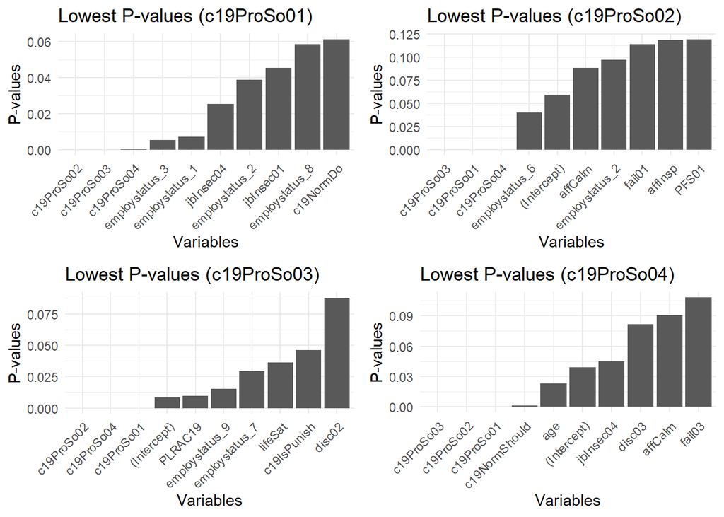

We can still determine that the pro-social values do affect each other in Ukraine as well. For external factors, let’s take a deeper dive into this.

[output not shown]

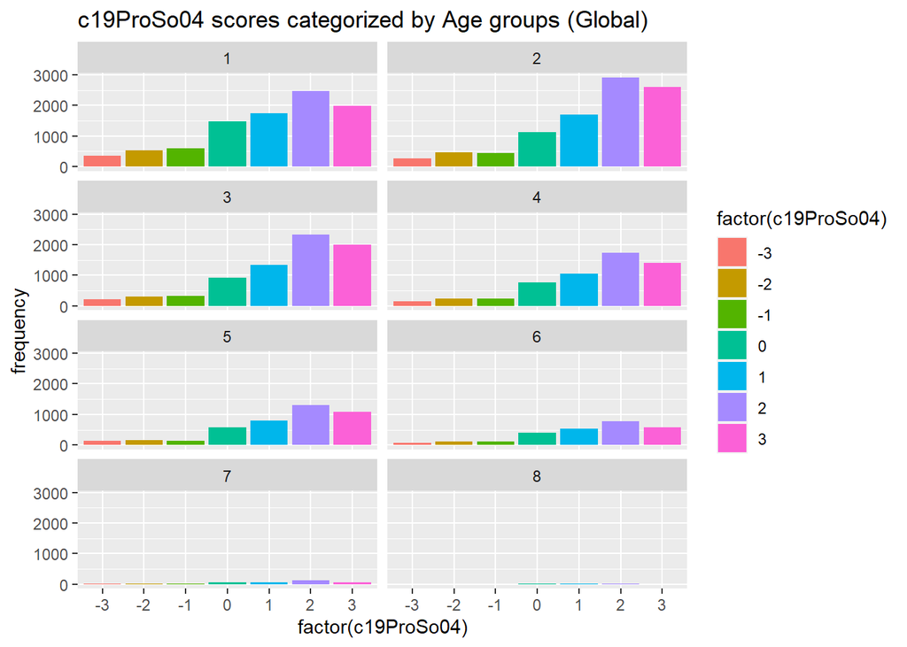

[output not shown]

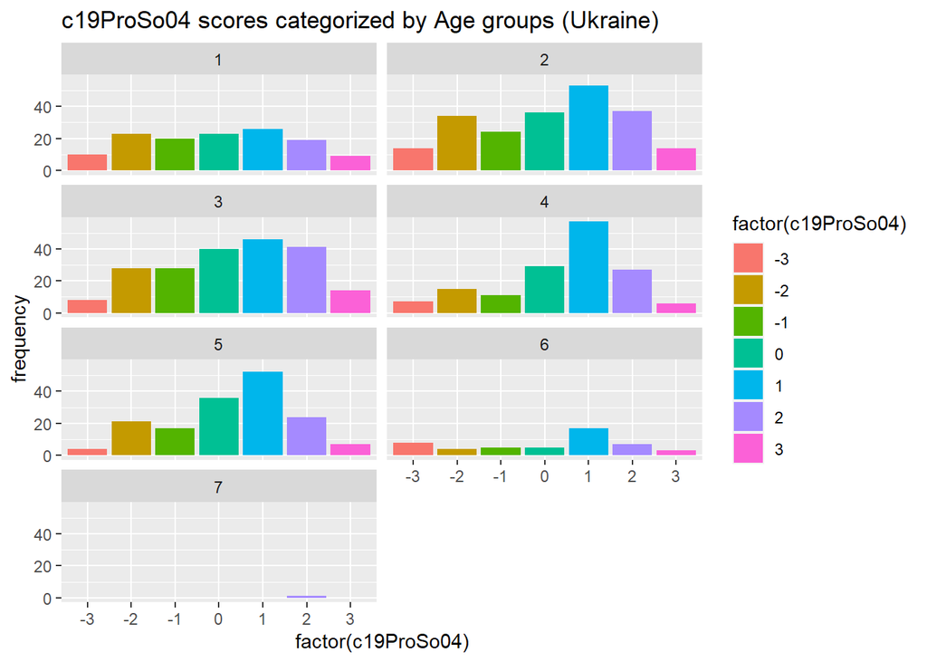

From the graphs above, we can see that Ukrainians are less likely to make personal sacrifices to prevent the spread of COVID-19. We can see this spike in groups 1, 2, 3 and 4, especially in age group 2 (25-34) where there exists a group which disagree with making personal sacrifices. The Global range however shows that people agree more that they should be making sacrifices to prevent the spread of the coronavirus.

Overall what we can conclude is that Corona Community Injunctive norms affect more on pro-social behaviors that revolve around socially helping others and oneself as well as trust in government and community. Age plays a factor in vulnerable groups most while Financial situations are the main factor in helping others in Ukraine. Financial factors play an important role in donating to help others in both Global and Ukraine datasets and in making personal sacrifices too. This can be attributed most likely because they are unable to make any sort of sacrifice without heavily affecting their livelihood in an adverse manner. Ukraine is a bit more sensitive towards their reluctance to donate and help out likely due to their own financial strain.

Clustering of groups of countries based on indicators (Question 3a)

Now, let’s cluster and find countries based on similar indicators towards Ukraine and their statistics.

We will be using the Global Health Security Index data set to help in clustering countries of similar GHS scores. GHS is the assessment for the countries’ global health security on how well they are prepared to respond to disease outbreaks from a score of 0 to 100. The hypothesis is that countries with similar GHS scores may link to similarities in Pro Social Behavior as their country’s readiness to respond to outbreaks is around the same. This data is retrieved from the Global Security Health Index which can be found here: https://www.ghsindex.org/

We will be comparing GHS scores in the year 2021. This is because that COVID-19 does not exist in 2019, and there is no available data for the year 2020.

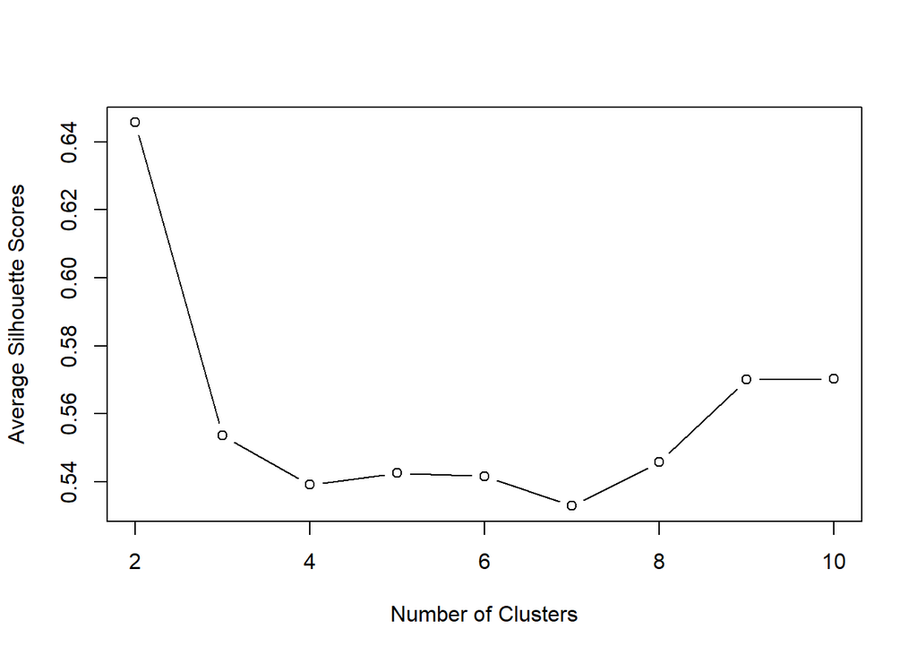

```r
ghs = read.csv("2021-GHS-Index-April-2022.csv")
ghs = ghs[ghs$Year == "2021",]
ghs[,3] = scale(ghs[,3])


silhouette_score <- function(k) {
  km = kmeans(ghs[, c("OVERALL.SCORE")], centers = k, nstart = 25)
  ss = silhouette(km$cluster, dist(ghs[, c("OVERALL.SCORE")]))
  mean(ss[,3])
}

k <- 2:10
avg_sil <- sapply(k, silhouette_score)
plot(k, type='b', avg_sil, xlab = "Number of Clusters", ylab= "Average Silhouette Scores", xlim=c(2,10))
```

From the data above, having 2 clusters give the best score by far but we will be using 9 clusters instead to find more specific countries. Let’s apply this into our data set

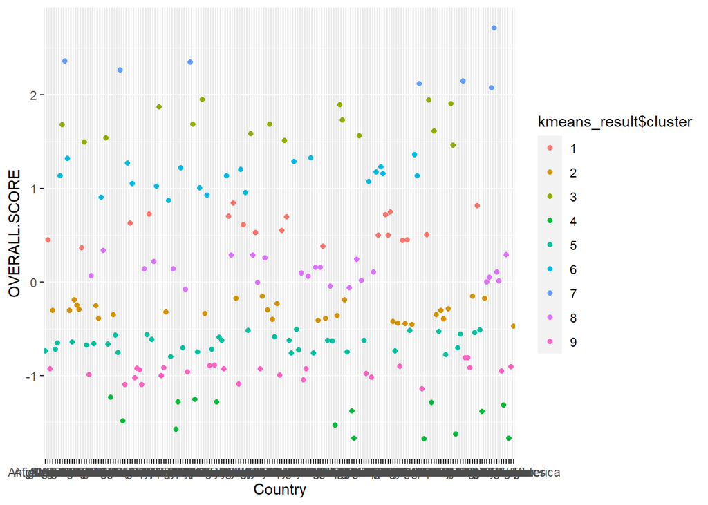

```r
kmeans_result = kmeans(ghs[,c("OVERALL.SCORE")], centers = 9, nstart = 25)

ghs$cluster = kmeans_result$cluster

ukraine_cluster = ghs[ghs$Country == "Ukraine",]
num = ukraine_cluster$cluster
ukraine_cluster2 = ghs[ghs$Country == "United Arab Emirates",]

a = ghs[ghs$cluster == num,]


ghs$Country = factor(ghs$Country)
kmeans_result$cluster = as.factor(kmeans_result$cluster)
ggplot(ghs,aes(Country,OVERALL.SCORE, color = kmeans_result$cluster)) + geom_point()
```

We are able to identify these few countries that are in the same cluster as Ukraine.

```r
a$Country
```

```
##  [1] "Bhutan"               "Brunei"               "Costa Rica"
##  [4] "Cyprus"               "El Salvador"          "Ethiopia"
##  [7] "India"                "Jordan"               "Kenya"
## [10] "Kyrgyz Republic"      "Malta"                "Mauritius"
## [13] "Moldova"              "Mongolia"             "Myanmar"
## [16] "Nigeria"              "North Macedonia"      "Oman"
## [19] "Paraguay"             "Ukraine"              "United Arab Emirates"
## [22] "Uruguay"              "Uzbekistan"           "Vietnam"
```

For comparison, we will be choosing Vietnam, India and United Arab Emirates.

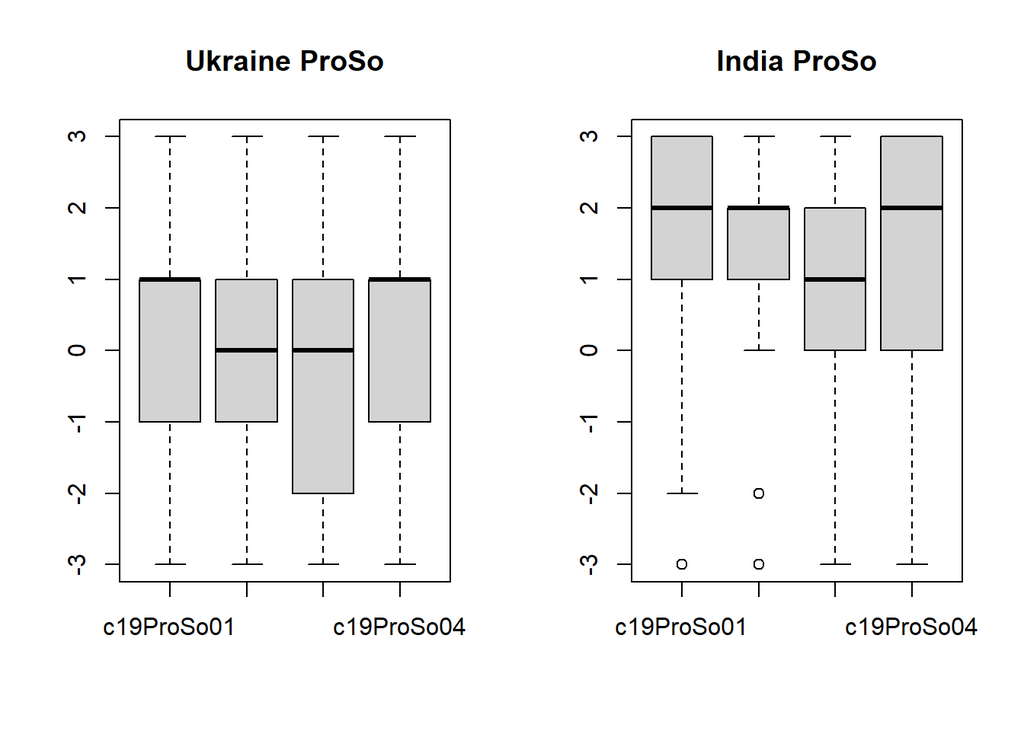

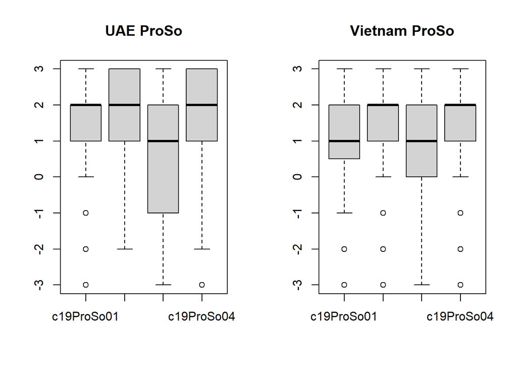

Based on the data collected, it seems that despite similar GHS scores, this does not seem to correlate to the Pro Social Behaviors. As seen here the UAE, India and Vietnam all have higher Pro Social Behavior scores in the people that took the survey as compared to Ukraine.

At the time being, let us find the strongest predictors using the same method we did for each of the 4 pro social behaviors

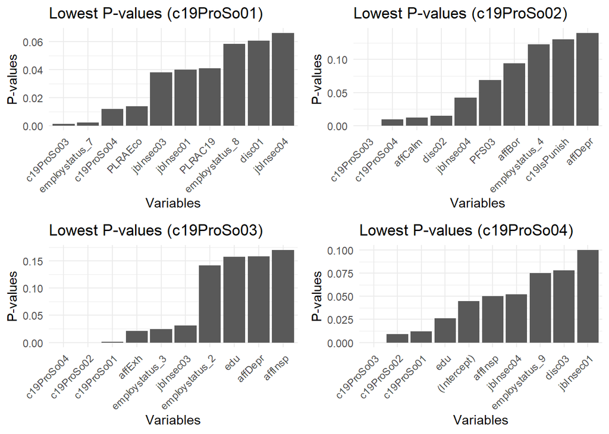

Due to the values of some of these countries not having enough rows, we have included all these countries into one continuous dataframe to analyse the predictors.

Lets dive into this more closely:

Overall the pro-social behaviors still correlate with each other. Hence we can see that their p-values are still the among the top 10 lowest predictors. We will be looking into other predictors in our analysis.

Overall a common theme that we can notice here is that these countries depend more on their financial situation and their feelings to make a decision on how likely they would engage in these pro-social behaviors while helping others and making donations follow a similar trend to both Ukraine and Global data, linking more towards how financially stable they are.

In a nutshell, here are the results that we have gotten:

- Global Analysis shows that trust in community is one of the most important factors in deciding on their pro-social behavior. This includes Corona Community Injunctive Behavior as well. Finance also plays an important factor here.
- Ukrainians, however, follow more on their Financial Situation to decide on their pro-social behavior. This can be seen as their strongest predictors usually revolve around their economical status (employstatus, PFS, jbInSec).
- The focus countries based on clustering shows less emphasis on their trust on community as compared to those of the Global values, but also incorporates their personal feelings into the mix as shown in c19ProSo03 and c19ProSo04. While Financial Situation factors in also, as similar with Global and Ukrainian statistics, they are not as prevalent.
- Overall Ukrainians are more in line with the focus country data, as seen where Ukrainians and the people from the focus countries have in common, which is depending on their financial situation to make pro-social choices. While Global data also backs up that statement, Community is a more important factor for them in this case.